# Lab 5

Nathan Preuss

2020-09-19

# Tasks

## Task 1

Find the working directory

```r
getwd()
```

```
## [1] "C:/Users/Nathan/Documents/R_Projects/MATH4753PREU0001/Lab5"
```

## Task 2

Made the mylab5.R file.

The following chunk of code produces the 5 graphs and then outputs the table for 10000 iterations. It further outputs a table comparing its output, dbinom, and the difference between the two.

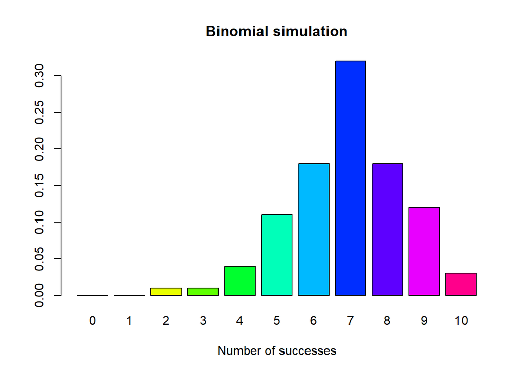

```r
# This a function that makes a barplot given a specific sample size and a probability
mybin=function(iter=100,n=10, p=0.5){
  # make a matrix to hold the samples
  #initially filled with NA's
  sam.mat=matrix(NA,nr=n,nc=iter, byrow=TRUE)
  #Make a vector to hold the number of successes in each trial
  succ=c()
  for( i in 1:iter){
    #Fill each column with a new sample
    sam.mat[,i]=sample(c(1,0),n,replace=TRUE, prob=c(p,1-p))
    #Calculate a statistic from the sample (this case it is the sum)
    succ[i]=sum(sam.mat[,i])
  }
  #Make a table of successes
  succ.tab=table(factor(succ,levels=0:n))
  #Make a barplot of the proportions
  barplot(succ.tab/(iter), col=rainbow(n+1), main="Binomial simulation", xlab="Number of successes")

  #only output the table if it is the last iteration
  if(iter == 10000)
  {
    # create vectors to turn into rows of the dataframe
    x = c(succ.tab/iter)
    y = c(dbinom(0, 10, 0.7), dbinom(1, 10, 0.7), dbinom(2, 10, 0.7), dbinom(3, 10, 0.7), dbinom(4, 10, 0.7), dbinom(5, 10, 0.7),dbinom(6, 10, 0.7),dbinom(7, 10, 0.7),dbinom(8, 10, 0.7),dbinom(9, 10, 0.7),dbinom(10, 10, 0.7))
    z = c(0:10)
    total = x-y


    #creating the finished dataframe in a somewhat inefficient, roundabout manner
    df = as.data.frame(t(x))
    df2 = as.data.frame((t(y)))
    df3 = as.data.frame(t(total))
    colnames(df) <- z
    colnames(df2) <- z
    colnames(df3) <- z
    dbin <- rbind(df, df2, df3)
    dbin[,] <-round(dbin[,],5)
    dbin <- data.frame(name = c("mybin", "dbinom", "difference"), dbin)
    dbin
  }
}

#5 different plots for each of the required iterations
mybin(iter=100,n=10, p=0.7)
```

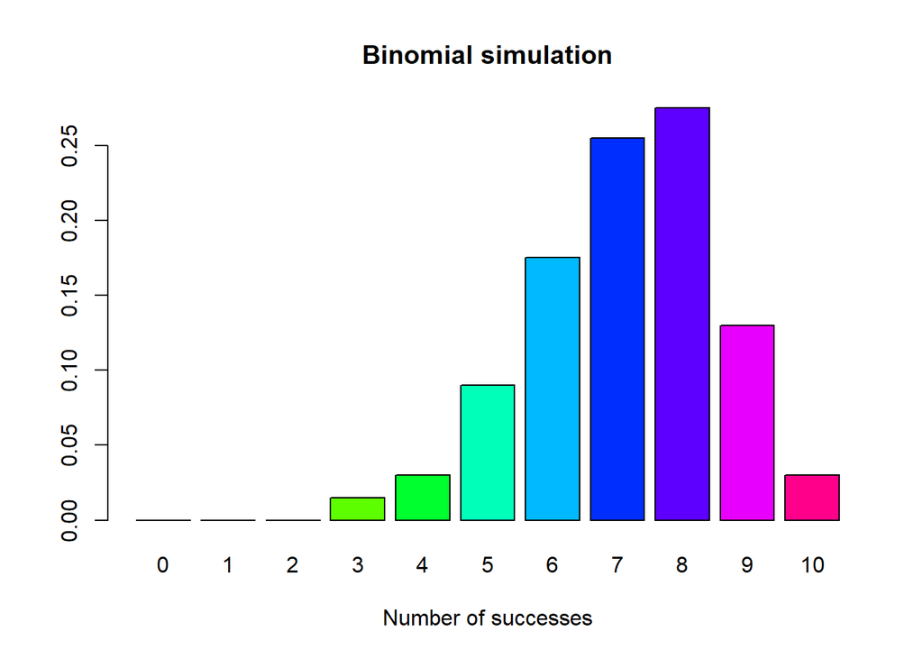

```r
mybin(iter=200,n=10, p=0.7)
```

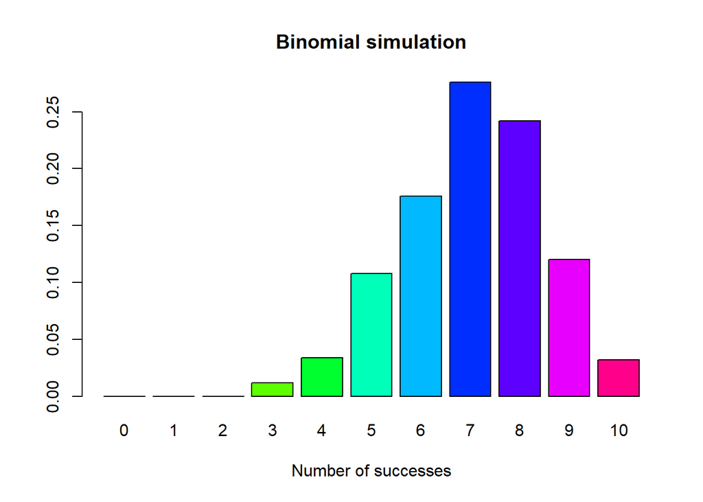

```r
mybin(iter=500,n=10, p=0.7)
```

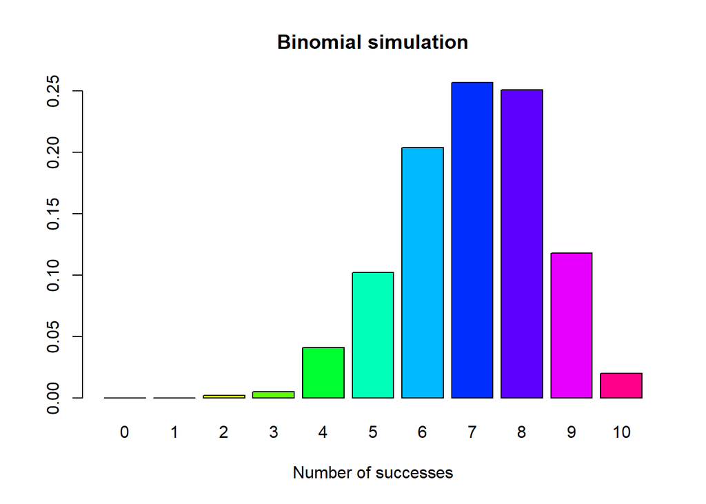

```r
mybin(iter=1000,n=10, p=0.7)
```

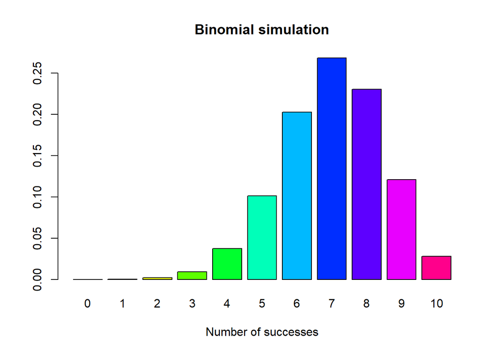

```
##         name     X0       X1      X2     X3      X4       X5      X6      X7
## 1      mybin  0e+00  0.00010 0.00190 0.0094 0.03720  0.10110 0.20290 0.26840
## 2     dbinom  1e-05  0.00014 0.00145 0.0090 0.03676  0.10292 0.20012 0.26683
## 3 difference -1e-05 -0.00004 0.00045 0.0004 0.00044 -0.00182 0.00278 0.00157
##         X8       X9      X10
## 1  0.23030  0.12090  0.02780
## 2  0.23347  0.12106  0.02825
## 3 -0.00317 -0.00016 -0.00045
```

```r
mybin(iter=10000,n=10, p=0.7)
```

The table above has 3 rows, the top one shows the values returned by the mybin function, the middle row shows the numbers gotten from dbinom, and the last row shows the difference between the 2. As the difference row in the table shows, there is very little difference between mybin and dbinom.

## Task 3

Creating the sample with and without replacement. Top output is without replacement and the bottom output is with replacement.

```r
#uhhhhhhhhhhhhhh, there should be a way to use this with prob, but I kept getting an error so I just hard coded the vector of 0 and 1
sample(c(1,1,1,1,1,1,1,1,1,1,1,1,0,0,0,0,0,0,0,0),size=5, replace=FALSE)
```

```
## [1] 1 0 0 0 0
```

```r
sample(c(0,1),size=5,prob=c(2/5,3/5),replace=TRUE)
```

```
## [1] 1 0 0 1 1
```

The following chunk of code produces the 5 graphs and then outputs the table for 10000 iterations. It further outputs a table comparing its output, dhyper, and the difference between the two.

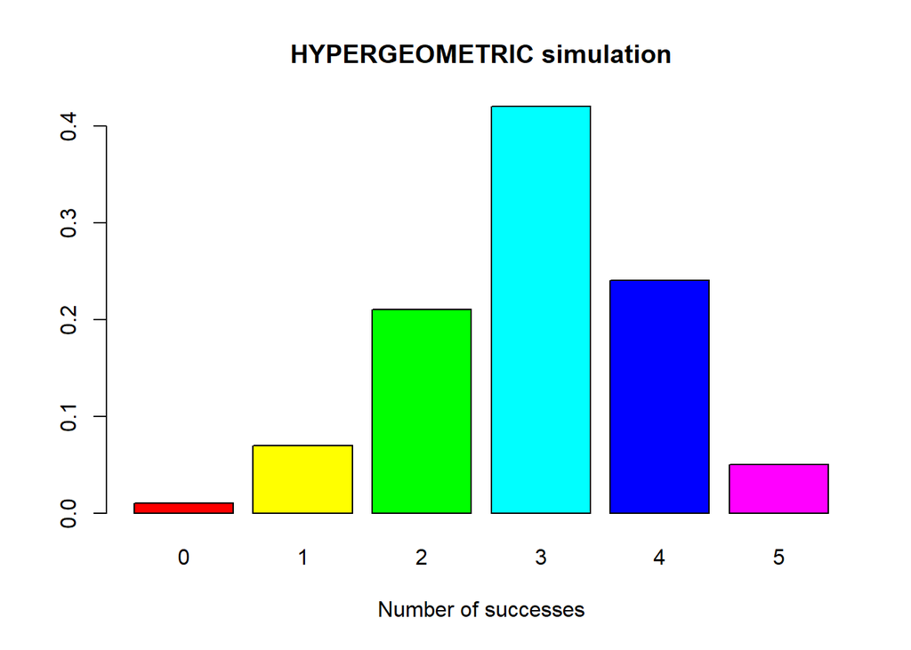

```r
myhyper=function(iter=100,N=20,r=12,n=5){
# make a matrix to hold the samples
#initially filled with NA's
sam.mat=matrix(NA,nr=n,nc=iter, byrow=TRUE)
#Make a vector to hold the number of successes over the trials
succ=c()
for( i in 1:iter){
#Fill each column with a new sample
sam.mat[,i]=sample(rep(c(1,0),c(r,N-r)),n,replace=FALSE)
#Calculate a statistic from the sample (this case it is the sum)
succ[i]=sum(sam.mat[,i])
}
#Make a table of successes
succ.tab=table(factor(succ,levels=0:n))
#Make a barplot of the proportions
barplot(succ.tab/(iter), col=rainbow(n+1), main="HYPERGEOMETRIC simulation", xlab="Number of successes")

#only output the table if it is the last iteration
  if(iter == 10000)
  {
    # create vectors to turn into rows of the dataframe
    x = c(succ.tab/iter)
    y = c(dhyper(0, 12, 8, 5), dhyper(1, 12, 8, 5), dhyper(2, 12, 8, 5), dhyper(3, 12, 8, 5), dhyper(4, 12, 8, 5), dhyper(5, 12, 8, 5))
    z = c(0:5)
    total = x-y


    #creating the finished dataframe in a somewhat inefficient, roundabout manner
    df = as.data.frame(t(x))
    df2 = as.data.frame((t(y)))
    df3 = as.data.frame(t(total))
    colnames(df) <- z
    colnames(df2) <- z
    colnames(df3) <- z
    dhyp <- rbind(df, df2, df3)
    dhyp[,] <-round(dhyp[,],5)
    dhyp <- data.frame(name = c("myhype", "dhyper", "difference"), dhyp)
    dhyp
  }
}

#5 different plots
myhyper(iter=100,n=5, N=20,r=12)
```

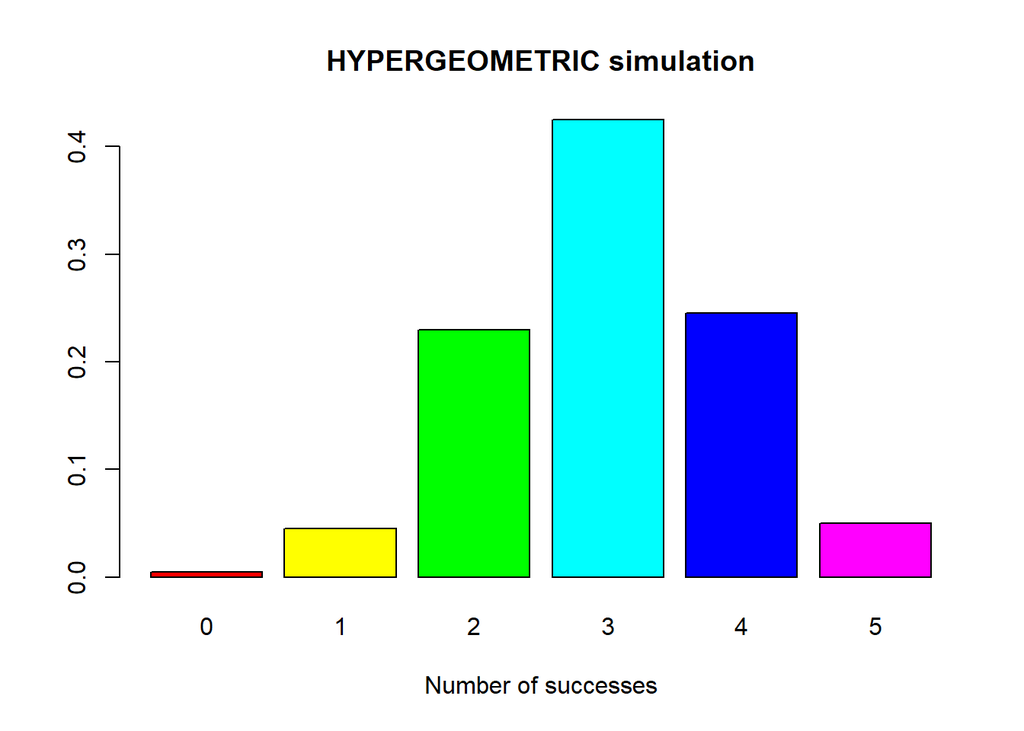

```r
myhyper(iter=200,n=5, N=20,r=12)
```

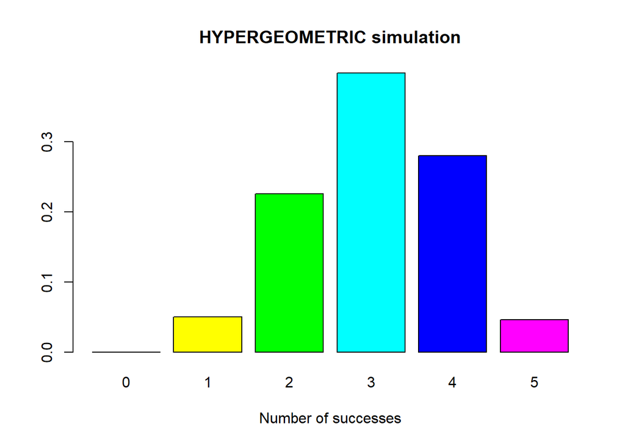

```r
myhyper(iter=500,n=5, N=20,r=12)
```

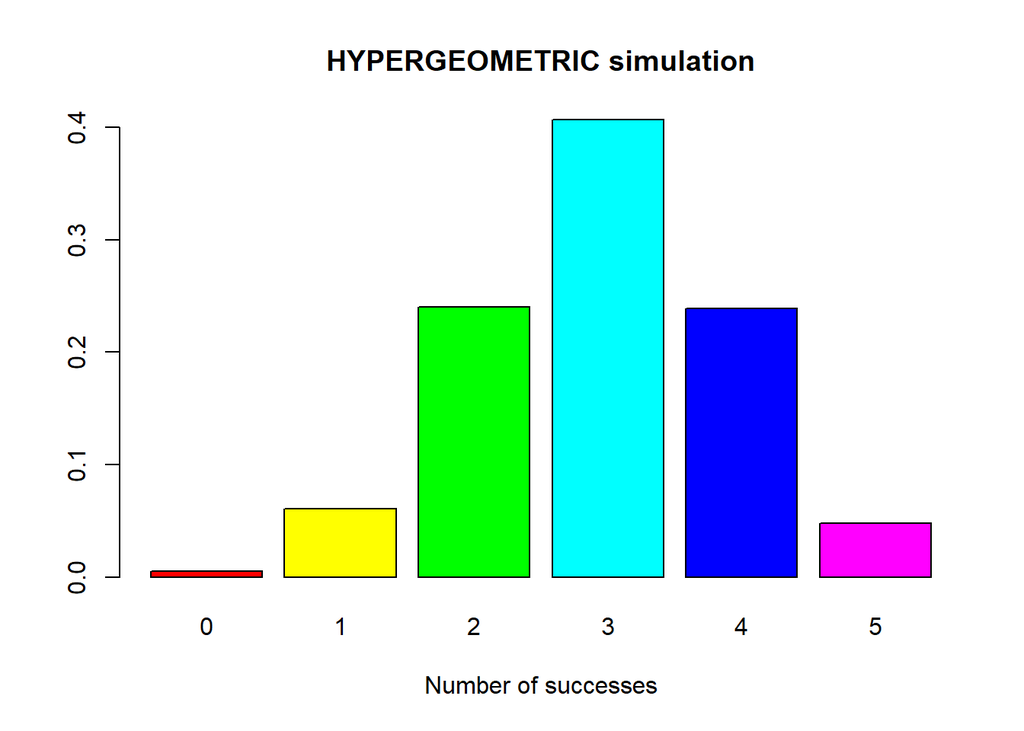

```r
myhyper(iter=1000,n=5, N=20,r=12)
```

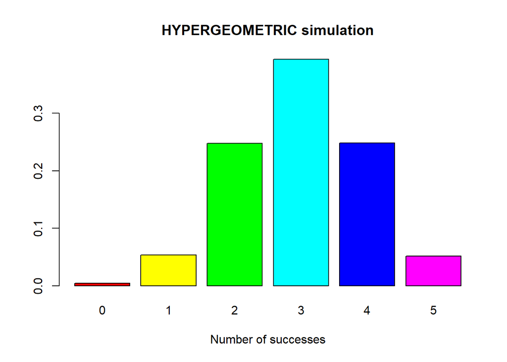

```
##         name      X0       X1      X2       X3       X4      X5
## 1     myhype 0.00410  0.05380 0.24810  0.39420  0.24830 0.05150
## 2     dhyper 0.00361  0.05418 0.23839  0.39732  0.25542 0.05108
## 3 difference 0.00049 -0.00038 0.00971 -0.00312 -0.00712 0.00042
```

```r
myhyper(iter=10000,n=5, N=20,r=12)
```

The table above has 3 rows, the top one shows the values returned by the myhyper function, the middle row shows the numbers gotten from dhyper, and the last row shows the difference between the 2. As the difference row in the table shows, there is very little difference between myhyper and dhyper.

## Task 4

From the looks of things, this function takes the number of items to choose from a sample as n, the number of iterations to run the sampling as iter, and a time length as arguments. The function then takes a sample of n items from 1 through 10, replacing each item after it has been sampled. It then turns the samples into a factor, and uses the factor to construct a barplot of an example sample for a given iteration.

After running mysample with the given parameters and after waiting for computer to process the 30 graphs, I saw that 30 graphs had been created, each showing a different sample iteration with all of the column values hovering around .10.

Ta-da! The plot appears below.

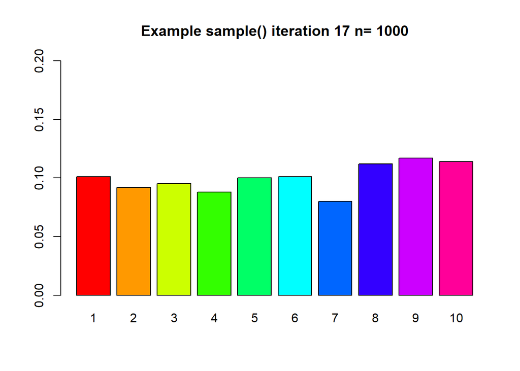

```r
mysample=function(n, iter=10,time=0.5){
  for( i in 1:iter){
    #make a sample
    s=sample(1:10,n,replace=TRUE)
    # turn the sample into a factor
    sf=factor(s,levels=1:10)
    #make a barplot

    # Edited to show only 1 graph
    if(i == 17)
    {
      barplot(table(sf)/n,beside=TRUE,col=rainbow(10),
      main=paste("Example sample()", " iteration ", i, " n= ", n,sep="") , ylim=c(0,0.2))
    }

    #release the table
    Sys.sleep(time)
  }
}

mysample(n=1000, iter=30, time = 1)
```

## Task 5

### Question 1

```r
choose(8,4)
```

```
## [1] 70
```

$${8 \choose 4} = 70$$

### Question 2

```r
1-ppois(4, 2)
```

```
## [1] 0.05265302
```

$$P(Y>4)\sim pois(\lambda = 2) = 0.0526$$

### Question 3

```r
dnbinom(x=10-3,size=3,prob=0.4)
```

```
## [1] 0.06449725
```

$$P(Y=10),Y\sim NegBin(p=0.4, r = 3) = 0.0645$$

### Question 4

```r
pbinom(8, 15, 0.4)
```

```
## [1] 0.9049526
```

$$P(Y \le 8),Y \sim Bin(n=15, p=0.4) = 0.9049$$

## Task 6

```r
MATH4753PREU0001::bindif(10000, 10, .7)
```

```
##         name     X0       X1      X2      X3      X4      X5       X6      X7
## 1     sample  0e+00  0.00000 0.00170  0.0087 0.03780 0.10820  0.19490 0.26820
## 2     dbinom  1e-05  0.00014 0.00145  0.0090 0.03676 0.10292  0.20012 0.26683
## 3 difference -1e-05 -0.00014 0.00025 -0.0003 0.00104 0.00528 -0.00522 0.00137
##         X8       X9      X10
## 1  0.23170  0.12090  0.02790
## 2  0.23347  0.12106  0.02825
## 3 -0.00177 -0.00016 -0.00035
```

```r
MATH4753PREU0001::bindif(10000, 15, .2)
```

```
##         name       X0      X1      X2       X3     X4       X5       X6      X7
## 1     sample  0.03050 0.13580  0.2285  0.24850 0.1949  0.10250  0.03970 0.01590
## 2     dbinom  0.03518 0.13194  0.2309  0.25014 0.1876  0.10318  0.04299 0.01382
## 3 difference -0.00468 0.00386 -0.0024 -0.00164 0.0073 -0.00068 -0.00329 0.00208
##         X8       X9   X10    X11 X12 X13 X14 X15
## 1  0.00320  0.00040 1e-04  0e+00   0   0   0   0
## 2  0.00345  0.00067 1e-04  1e-05   0   0   0   0
## 3 -0.00025 -0.00027 0e+00 -1e-05   0   0   0   0
```